# Lecture 12: Polytomous IRT Models

Bayesian Psychometric Modeling

```r
# Install/Load Packages ===============================================================================================
if (!require(R2jags)) install.packages("R2jags")
```

```
## Linked to JAGS 4.3.0
```

```
## Loaded modules: basemod,bugs
```

```r
library(R2jags)

if (!require(mvtnorm)) install.packages("mvtnorm")
library(mvtnorm)
```

## Item Response Models for Polytomous Data: Example Analyses

Today’s example is from a bootstrap resample of 177 undergradutes at a large state university in the midwest. The survey was a measure of 10 questions about their beliefs in various conspiracy theories that were being passed around the internet in the early 2010s. Additionally, gender was included in the survey.

All items responses were on a 5-point Likert scale where:

- 1 = Strongly Disagree
- 2 = Disagree
- 3 = Neither Agree or Disagree
- 4 = Agree
- 5 = Strongly Agree

**Questions:**

1. The U.S. invasion of Iraq was not part of a campaign to fight terrorism, but was driven by oil companies and Jews in the U.S. and Israel.
2. Certain U.S. government officials planned the attacks of September 11, 2001 because they wanted the United States to go to war in the Middle East.
3. President Barack Obama was not really born in the United States and does not have an authentic Hawaiian birth certificate.
4. The current financial crisis was secretly orchestrated by a small group of Wall Street bankers to extend the power of the Federal Reserve and further their control of the world’s economy.
5. Vapor trails left by aircraft are actually chemical agents deliberately sprayed in a clandestine program directed by government officials.
6. Billionaire George Soros is behind a hidden plot to destabilize the American government, take control of the media, and put the world under his control.
7. The U.S. government is mandating the switch to compact fluorescent light bulbs because such lights make people more obedient and easier to control.
8. Government officials are covertly Building a 12-lane "NAFTA superhighway" that runs from Mexico to Canada through America’s heartland.
9. Government officials purposely developed and spread drugs like crack-cocaine and diseases like AIDS in order to destroy the African American community.
10. God sent Hurricane Katrina to punish America for its sins.

**Also note: these analyses take an excessive amount of time to run. So, please follow along with the HTML file through class.**

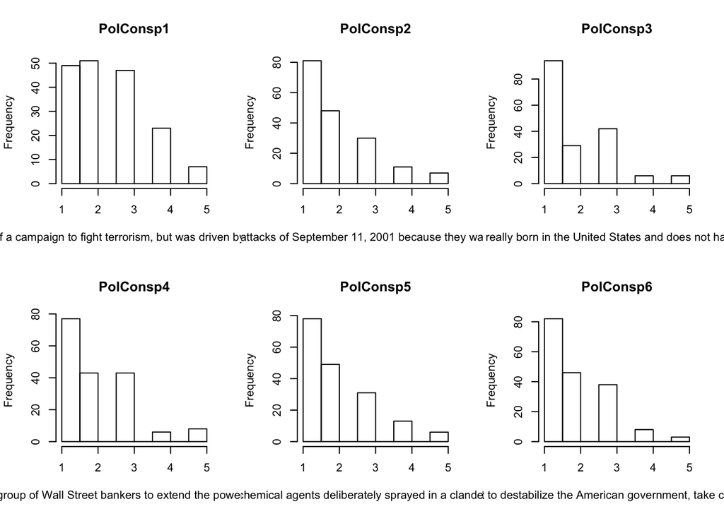

```r
# read in data:
conspiracy = read.csv("conspiracies.csv")

par(mfrow = c(2,3))
# plot each item
hist(conspiracy$PolConsp1, main = "PolConsp1", xlab = "1. The U.S. invasion of Iraq was not part of a campaign to fight terrorism, but was driven by oil companies and Jews in the U.S. and Israel.")
hist(conspiracy$PolConsp2, main = "PolConsp2", xlab = "2. Certain U.S. government officials planned the attacks of September 11, 2001 because they wanted the United States to go to war in the Middle East.")
hist(conspiracy$PolConsp3, main = "PolConsp3", xlab = "3. President Barack Obama was not really born in the United States and does not have an authentic Hawaiian birth certificate.")
hist(conspiracy$PolConsp4, main = "PolConsp4", xlab = "4. The current financial crisis was secretly orchestrated by a small group of Wall Street bankers to extend the power of the Federal Reserve and further their control of the world's economy.")
hist(conspiracy$PolConsp5, main = "PolConsp5", xlab = "5. Vapor trails left by aircraft are actually chemical agents deliberately sprayed in a clandestine program directed by government officials.")
hist(conspiracy$PolConsp6, main = "PolConsp6", xlab = "6. Billionaire George Soros is behind a hidden plot to destabilize the American government, take control of the media, and put the world under his control.")
```

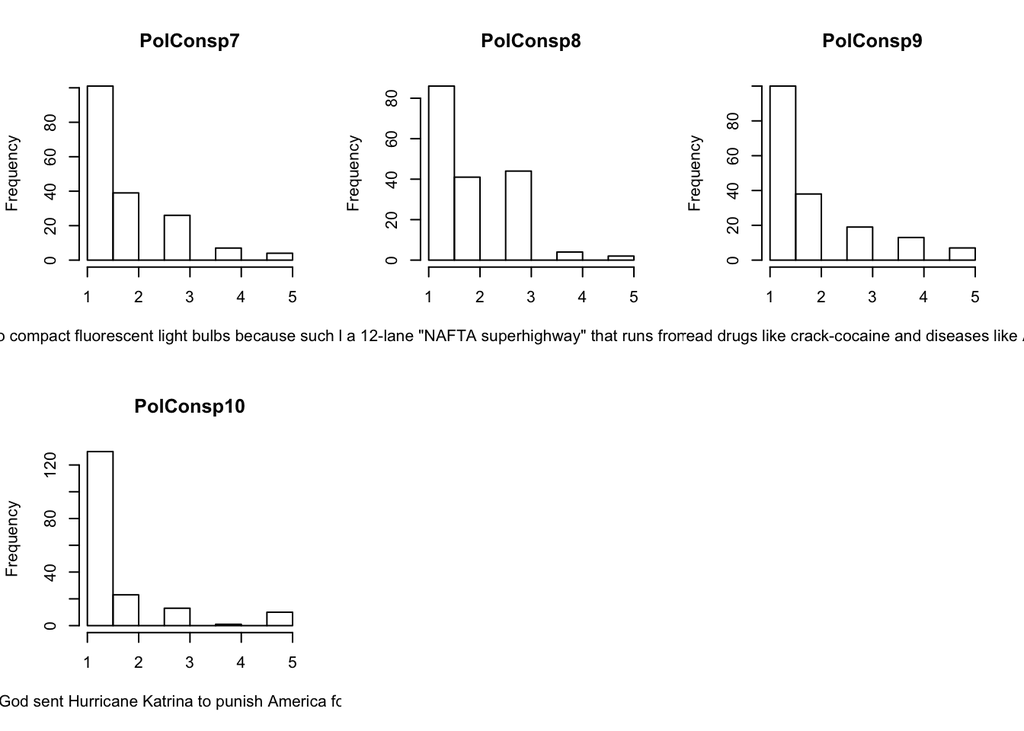

```r
hist(conspiracy$PolConsp7, main = "PolConsp7", xlab = "7. The U.S. government is mandating the switch to compact fluorescent light bulbs because such lights make people more obedient and easier to control.")
hist(conspiracy$PolConsp8, main = "PolConsp8", xlab = "8. Government officials are covertly Building a 12-lane \"NAFTA superhighway\" that runs from Mexico to Canada through America's heartland.")
hist(conspiracy$PolConsp9, main = "PolConsp9", xlab = "9. Government officials purposely developed and spread drugs like crack-cocaine and diseases like AIDS in order to destroy the African American community.")
hist(conspiracy$PolConsp10, main = "PolConsp10", xlab = "10. God sent Hurricane Katrina to punish America for its sins.")
```

## Model 0: Unidimensional Confirmatory Factor Analysis Model (Lecture 9)

```r
model00.function = function(){
  # measurement model specification
  for (person in 1:N){
    for (item in 1:I){
      mean[person, item] = mu[item] + lambda[item]*xfactor[person]
      X[person, item] ~ dnorm(mean[person,item], inv.psi[item])
    }
  }

  # prior distributions for the factor:
  for (person in 1:N){
    xfactor[person] ~ dnorm(0, 1)
  }

  # prior distributions for the measurement model mean/precision parameters
  for (item in 1:I){
    mu[item] ~ dnorm(mu.mean.0, mu.precision.0)
    inv.psi[item] ~ dgamma(psi.alpha.0, psi.beta.0[item])
  }

  # prior distributions for the loadings
  for (item in 1:I){
    lambda[item] ~ dnorm(lambda.mean.0, lambda.precision.0); T(0,)
  }

  for (item in 1:I){
    psi[item] <- 1/inv.psi[item]
  }

}
```

```r
# model specs:
nItems = ncol(conspiracy[paste0("PolConsp", 1:10)])

# specification of prior values for measurement model parameters:
#   item means
mu.mean.0 = 3
mu.variance.0 = 1000
mu.precision.0 = 1 / mu.variance.0

#   Factor loadings
lambda.mean.0 = 0
lambda.variance.0 = 1000
lambda.precision.0 = 1 / lambda.variance.0

# unique variances
psi.df.0 = 1
psi.var.0 = apply(X = conspiracy[paste0("PolConsp", 1:10)], MARGIN = 2, FUN = var)
psi.alpha.0 = psi.df.0 / 2
psi.beta.0 = (psi.df.0 * psi.var.0) / 2

model00.data = list(
  N = nrow(conspiracy),
  X = conspiracy[paste0("PolConsp", 1:10)],
  I = nItems,
  mu.mean.0 = mu.mean.0,
  mu.precision.0 = mu.precision.0,
  lambda.mean.0 = lambda.mean.0,
  lambda.precision.0 = lambda.precision.0,
  psi.alpha.0 = psi.alpha.0,
  psi.beta.0 = psi.beta.0
)

model00.parameters = c("mu", "lambda",  "psi", "deviance", "xfactor")

model00.seed = 23022019
```

Here, we will use the R2jags `jags.parallel()` function, which will run somewhat faster (one chain per core):

```r
model00.r2jags =  jags.parallel(
  data = model00.data,
  parameters.to.save = model00.parameters,
  model.file = model00.function,
  n.chains = 4,
  n.iter = 5000,
  n.thin = 1,
  n.burnin = 3000,
  jags.seed = model00.seed
)

model00.r2jags
```

```
## Inference for Bugs model at "model00.function", fit using jags,
##  4 chains, each with 5000 iterations (first 3000 discarded)
##  n.sims = 8000 iterations saved
##               mu.vect sd.vect     2.5%      25%      50%      75%    97.5%
## lambda[1]       0.751   0.148    0.584    0.684    0.738    0.795    0.937
## lambda[2]       0.886   0.165    0.727    0.820    0.871    0.924    1.059
## lambda[3]       0.815   0.149    0.659    0.750    0.802    0.856    0.987
## lambda[4]       0.859   0.157    0.701    0.792    0.845    0.899    1.025
## lambda[5]       1.014   0.180    0.866    0.950    0.997    1.047    1.170
## lambda[6]       0.914   0.155    0.776    0.856    0.898    0.945    1.057
## lambda[7]       0.779   0.143    0.636    0.719    0.765    0.813    0.937
## lambda[8]       0.867   0.153    0.740    0.811    0.853    0.895    1.002
## lambda[9]       0.875   0.165    0.714    0.807    0.861    0.914    1.050
## lambda[10]      0.686   0.146    0.527    0.622    0.674    0.729    0.861
## mu[1]           2.370   0.087    2.199    2.311    2.370    2.428    2.540
## mu[2]           1.956   0.087    1.783    1.899    1.957    2.014    2.126
## mu[3]           1.878   0.085    1.713    1.820    1.877    1.934    2.048
## mu[4]           2.013   0.086    1.844    1.957    2.013    2.070    2.181
## mu[5]           1.985   0.088    1.816    1.928    1.985    2.044    2.156
## mu[6]           1.894   0.079    1.742    1.843    1.894    1.947    2.050
## mu[7]           1.725   0.079    1.572    1.673    1.725    1.778    1.878
## mu[8]           1.844   0.076    1.699    1.795    1.844    1.894    1.990
## mu[9]           1.810   0.089    1.638    1.750    1.810    1.869    1.985
## mu[10]          1.521   0.083    1.362    1.466    1.520    1.575    1.685
## psi[1]          0.796   0.090    0.638    0.734    0.790    0.851    0.996
## psi[2]          0.544   0.074    0.430    0.499    0.538    0.583    0.686
## psi[3]          0.613   0.084    0.485    0.562    0.607    0.656    0.765
## psi[4]          0.575   0.077    0.456    0.527    0.570    0.617    0.721
## psi[5]          0.304   0.060    0.230    0.274    0.300    0.329    0.389
## psi[6]          0.262   0.056    0.200    0.237    0.259    0.282    0.335
## psi[7]          0.474   0.076    0.377    0.435    0.470    0.507    0.594
## psi[8]          0.236   0.057    0.181    0.214    0.233    0.254    0.302
## psi[9]          0.615   0.087    0.489    0.563    0.609    0.657    0.771
## psi[10]         0.708   0.095    0.568    0.650    0.701    0.756    0.878
## xfactor[1]      0.011   0.248   -0.479   -0.154    0.009    0.179    0.493
## xfactor[2]      1.510   0.277    0.969    1.333    1.511    1.690    2.051
## xfactor[3]      1.683   0.286    1.132    1.501    1.687    1.873    2.225
## xfactor[4]     -0.927   0.252   -1.420   -1.094   -0.920   -0.759   -0.441
## xfactor[5]      0.036   0.245   -0.447   -0.128    0.036    0.201    0.521
## xfactor[6]     -0.974   0.256   -1.471   -1.146   -0.977   -0.806   -0.454
```

[output cut: 373 more lines]

```
## xfactor[171] 1.001  6300
## xfactor[172] 1.001  5200
## xfactor[173] 1.001  8000
## xfactor[174] 1.001  8000
## xfactor[175] 1.002  3200
## xfactor[176] 1.001  8000
## xfactor[177] 1.001  6500
## deviance     1.001  8000
##
## For each parameter, n.eff is a crude measure of effective sample size,
## and Rhat is the potential scale reduction factor (at convergence, Rhat=1).
##
## DIC info (using the rule, pD = var(deviance)/2)
## pD = 860.8 and DIC = 4535.7
## DIC is an estimate of expected predictive error (lower deviance is better).
```

Convergence looks good. Let’s look at model fit using a posterior predictive model check:

```r
# list number of simulated data sets
nSimulatedDataSets = 5000

# create one large matrix of posterior value by disentangling chains
model00.Posterior.all = model00.r2jags$BUGSoutput$sims.matrix

# determine columns of posterior that go into each model matrix
muCols = grep(x = colnames(model00.Posterior.all), pattern = "mu")
lambdaCols = grep(x = colnames(model00.Posterior.all), pattern = "lambda")
psiCols = grep(x = colnames(model00.Posterior.all), pattern = "psi")

# save simulated correlations:
simCorModel00 = matrix(data = NA, nrow = nSimulatedDataSets, ncol = nItems*(nItems-1)/2)

# loop through data sets (can be sped up with functions and lapply)
pb = txtProgressBar()
sim = 1
for (sim in 1:nSimulatedDataSets){

  # draw sample from one iteration of posterior chain
  iternum = sample(x = 1:nrow(model00.Posterior.all), size = 1, replace = TRUE)

  # get parameters for that sample: put into factor model matrices for easier generation of data
  mu = matrix(data = model00.Posterior.all[iternum, muCols], ncol = 1)
  lambda = matrix(data = model00.Posterior.all[iternum, lambdaCols], ncol = 1)
  psi = diag(model00.Posterior.all[iternum, psiCols])

  # create model-implied mean and covariance matrix (marginal for X)
  meanVec = mu
  covMat = lambda %*% t(lambda) + psi

  # randomly draw data with same sample size from MVN with mean=meanVec and cov=covMat
  simData = rmvnorm(n = nrow(conspiracy), mean = meanVec, sigma = covMat)

  # create sample statistics from simulated data (we'll use correlation matrix, starting with upper triangle)
  simCorModel00[sim,] = matrix(data = c(cor(simData)[upper.tri(cor(simData))]), nrow = 1)

  setTxtProgressBar(pb = pb, value = sim/nSimulatedDataSets)
}
close(pb)
```

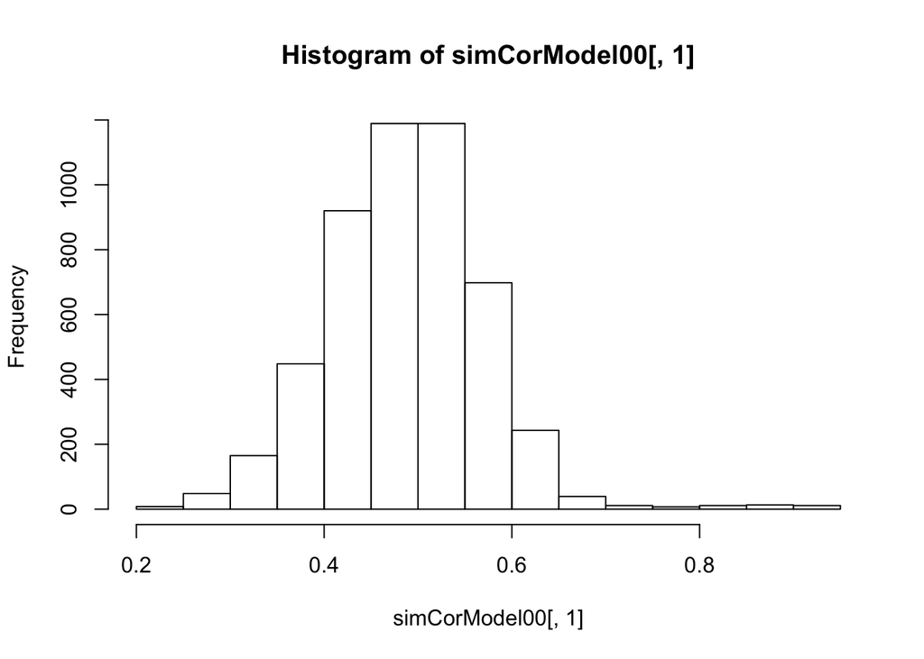

```r
# label values of simCor to ensure we have the right comparison
corNames = NULL
for (i in 1:(ncol(simData)-1)){
  for (j in (i+1):ncol(simData)){
    corNames = c(corNames, paste0("cor", i, "." , j))
  }
}
colnames(simCorModel00) = corNames

# show how one correlation compares to distribution of simulated correlations
dataCor = cor(conspiracy[paste0("PolConsp", 1:10)])
hist(simCorModel00[,1])
```

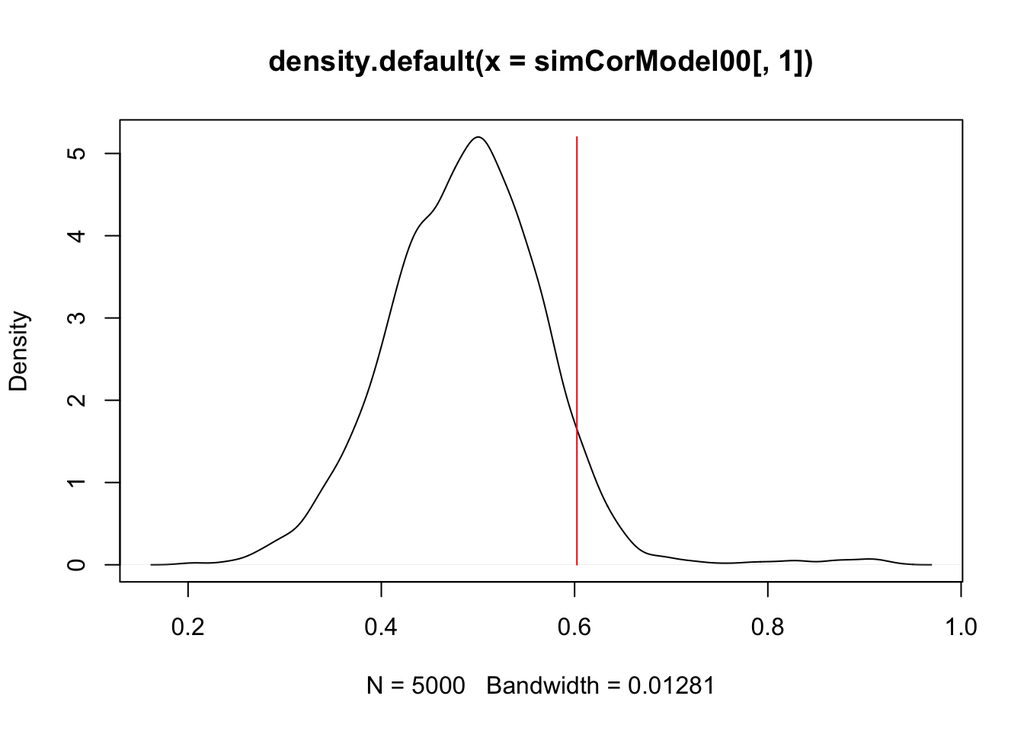

```r
plot(density(simCorModel00[,1]))
lines(x = c(dataCor[1,2], dataCor[1,2]), y = c(0, max(density(simCorModel00[,1])$y)), col = 2)
```

```r
quantile(simCorModel00[,1])
```

```
##        0%       25%       50%       75%      100%
## 0.2002283 0.4350313 0.4898251 0.5397899 0.9307775
```

```r
mean(simCorModel00[,1])
```

```
## [1] 0.4882778
```

```r
dataCor[1,2]
```

```
## [1] 0.6024186
```

```r
# create quantiles of correlations to see where each observed correlation falls
corQuantiles00 = NULL

# compute the quantiles of the observed correlations:
col = 1
for (i in 1:(ncol(simData)-1)){
  for (j in (i+1):ncol(simData)){
    # get empirical CDF of simulated correlation distribution
    corEcdf = ecdf(simCorModel00[,col])
    corQuantiles00 = rbind(corQuantiles00, c(i, j, summary(corEcdf), dataCor[i,j], corEcdf(dataCor[i,j])))

    col = col + 1
  }
}
colnames(corQuantiles00)[1:2] = c("Item 1", "Item 2")
colnames(corQuantiles00)[9:10] = c("ObsCor", "CorPctile")
corQuantiles00[which(corQuantiles00[,10] > .975 | corQuantiles00[,10] < .025),]
```

```
##       Item 1 Item 2       Min.   1st Qu.    Median      Mean   3rd Qu.
##  [1,]      1      9 0.45425665 0.6294442 0.6708608 0.6689107 0.7074606
##  [2,]      1     10 0.30727052 0.5844311 0.6280739 0.6269995 0.6687113
##  [3,]      2      3 0.40579259 0.6135203 0.6538804 0.6528493 0.6931736
##  [4,]      2      7 0.42204091 0.6072312 0.6510010 0.6477776 0.6882155
##  [5,]      2      8 0.57821986 0.7312577 0.7620189 0.7613088 0.7914974
##  [6,]      2     10 0.27924146 0.5241861 0.5704591 0.5690361 0.6140091
##  [7,]      3      9 0.40554202 0.6245726 0.6645409 0.6635304 0.7024296
##  [8,]      4      6 0.55643118 0.7316993 0.7624434 0.7615924 0.7916390
##  [9,]      4      7 0.55284800 0.7250600 0.7571214 0.7556560 0.7867422
## [10,]      5      6 0.24409799 0.4795961 0.5278474 0.5285482 0.5745769
## [11,]      6      8 0.06700793 0.3443331 0.4007916 0.4000156 0.4533819
## [12,]      7      8 0.14715207 0.4143572 0.4665773 0.4669420 0.5170749
##            Max.    ObsCor CorPctile
##  [1,] 0.9684044 0.4420860    0.0000
##  [2,] 0.9636735 0.2568334    0.0000
##  [3,] 0.9630845 0.5176819    0.0208
##  [4,] 0.9606250 0.4721628    0.0056
##  [5,] 0.9786089 0.6317705    0.0044
##  [6,] 0.9488104 0.4121264    0.0200
##  [7,] 0.9638030 0.3912734    0.0000
##  [8,] 0.9787088 0.6251455    0.0046
##  [9,] 0.9758921 0.4676834    0.0000
## [10,] 0.9404575 0.7366890    0.9894
## [11,] 0.9112933 0.7557355    0.9926
## [12,] 0.9197547 0.6611475    0.9886
```

### Model 1: Unidimensional Graded Response Model with Normal Ogive

```r
# marker item:
model01.function = function(){

  # measurement model specification
    for (person in 1:N){
      for (item in 1:I){

        # form cumulative probability item response functions
        CProb[person, item, 1] <- 1
        for (cat in 2:C[item]){
          CProb[person, item, cat] <- phi(a[item]*(theta[person]-b[item, (cat-1)]))
        }

        # form probability response is equal to each category
        for (cat in 1:(C[item] - 1)){
          Prob[person, item, cat] <- CProb[person, item, cat] - CProb[person, item, cat+1]
        }
        Prob[person, item, C[item]] <- CProb[person, item, C[item]]

        X[person, item] ~ dcat(Prob[person, item, 1:C[item]])
      }
    }

  # prior distributions for the factor:
    for (person in 1:N){
      theta[person] ~ dnorm(0, 1)
    }

  # prior distributions for the measurement model mean/precision parameters
    for (item in 1:I){

      # create parameters that are unbounded, then sort
      for (cat in 1:(C[item]-1)){
        b.star[item, cat] ~ dnorm(b.mean.0, b.precision.0)
      }
      b[item, 1:(C[item]-1)] <- sort(b.star[item, 1:(C[item]-1)])

      # loadings are set to be all positive
      a[item] ~ dnorm(a.mean.0, a.precision.0);T(0,)

    }

}
```

```r
nItems = 10

# specification of prior values for measurement model parameters:
#   item intercepts
b.mean.0 = 0
b.variance.0 = 100
b.precision.0 = 1 / b.variance.0

#   Factor loadings -- these are the discriminations
a.mean.0 = 0
a.variance.0 = 100
a.precision.0 = 1 / a.variance.0

# next, create data for JAGS to use:
model01.data = list(
  N = nrow(conspiracy),
  X = conspiracy,
  C = unlist(apply(X = conspiracy[,1:10], MARGIN = 2, FUN = max)),
  I = 10,
  b.mean.0 = b.mean.0,
  b.precision.0 = b.precision.0,
  a.mean.0 = a.mean.0,
  a.precision.0 = a.precision.0
)

model01.init = function(){
  list("a" = runif(10, 1, 2),
       "b.star" = cbind(rep(1, 10), rep(0, 10), rep(-1, 10), rep(-2, 10)))
}

model01.parameters = c("a", "b",  "theta")

model01.seed = 16042019
```

Here, we will use the R2jags `jags.parallel()` function, which will run somewhat faster (one chain per core):

```r
model01.r2jags =  jags.parallel(
  data = model01.data,
  inits = model01.init,
  parameters.to.save = model01.parameters,
  model.file = model01.function,
  n.chains = 4,
  n.iter = 5000,
  n.thin = 1,
  n.burnin = 3000,
  jags.seed = model01.seed
)

model01.r2jags
```

```
## Inference for Bugs model at "model01.function", fit using jags,
##  4 chains, each with 5000 iterations (first 3000 discarded)
##  n.sims = 8000 iterations saved
##             mu.vect sd.vect     2.5%      25%      50%      75%    97.5%
## a[1]          0.956   0.122    0.727    0.872    0.954    1.036    1.207
## a[2]          1.357   0.179    1.021    1.234    1.349    1.473    1.732
## a[3]          1.170   0.163    0.868    1.056    1.164    1.276    1.509
## a[4]          1.377   0.175    1.051    1.256    1.371    1.488    1.733
## a[5]          2.148   0.305    1.610    1.940    2.124    2.333    2.809
## a[6]          2.205   0.298    1.688    1.994    2.187    2.392    2.852
## a[7]          1.410   0.202    1.043    1.275    1.398    1.537    1.840
## a[8]          2.350   0.359    1.749    2.100    2.324    2.570    3.126
## a[9]          1.342   0.190    0.994    1.210    1.330    1.463    1.746
## a[10]         1.230   0.214    0.858    1.077    1.212    1.368    1.690
## b[1,1]       -0.885   0.174   -1.240   -0.999   -0.878   -0.766   -0.560
## b[2,1]       -0.113   0.122   -0.357   -0.195   -0.113   -0.029    0.122
## b[3,1]        0.164   0.123   -0.082    0.081    0.166    0.246    0.401
## b[4,1]       -0.163   0.123   -0.412   -0.244   -0.162   -0.080    0.073
## b[5,1]       -0.127   0.106   -0.333   -0.201   -0.127   -0.054    0.076
## b[6,1]       -0.036   0.108   -0.246   -0.106   -0.036    0.036    0.171
## b[7,1]        0.286   0.117    0.059    0.207    0.286    0.364    0.512
## b[8,1]        0.043   0.105   -0.165   -0.028    0.046    0.115    0.245
## b[9,1]        0.253   0.123    0.010    0.169    0.253    0.335    0.496
## b[10,1]       0.890   0.147    0.620    0.790    0.882    0.982    1.199
## b[1,2]        0.333   0.138    0.060    0.241    0.332    0.427    0.603
## b[2,2]        0.854   0.134    0.610    0.760    0.847    0.942    1.132
## b[3,2]        0.749   0.138    0.493    0.653    0.745    0.839    1.037
## b[4,2]        0.692   0.125    0.456    0.606    0.691    0.771    0.953
## b[5,2]        0.719   0.114    0.501    0.643    0.716    0.790    0.959
## b[6,2]        0.734   0.112    0.522    0.658    0.731    0.806    0.964
## b[7,2]        1.033   0.150    0.751    0.933    1.028    1.125    1.347
## b[8,2]        0.693   0.110    0.482    0.620    0.690    0.764    0.919
## b[9,2]        1.046   0.149    0.768    0.946    1.038    1.141    1.350
## b[10,2]       1.496   0.206    1.143    1.351    1.475    1.626    1.943
## b[1,3]        1.423   0.200    1.068    1.285    1.411    1.548    1.854
## b[2,3]        1.628   0.193    1.289    1.493    1.614    1.751    2.052
## b[3,3]        2.014   0.258    1.545    1.836    1.998    2.177    2.559
## b[4,3]        1.768   0.204    1.399    1.624    1.752    1.895    2.210
## b[5,3]        1.417   0.153    1.137    1.314    1.412    1.509    1.746
## b[6,3]        1.708   0.172    1.394    1.590    1.702    1.817    2.073
```

[output cut: 413 more lines]

```
## theta[171] 1.002  1600
## theta[172] 1.010   260
## theta[173] 1.013   210
## theta[174] 1.002  1500
## theta[175] 1.003  1300
## theta[176] 1.002  1500
## theta[177] 1.006   470
## deviance   1.003  1300
##
## For each parameter, n.eff is a crude measure of effective sample size,
## and Rhat is the potential scale reduction factor (at convergence, Rhat=1).
##
## DIC info (using the rule, pD = var(deviance)/2)
## pD = 257.2 and DIC = 3093.5
## DIC is an estimate of expected predictive error (lower deviance is better).
```

Now, let’s look at model fit. We will have to use a slightly different version of the syntax from before:

```r
# list number of simulated data sets
nSimulatedDataSets = 5000

# create one large matrix of posterior values
model01.Posterior.all = model01.r2jags$BUGSoutput$sims.matrix
dim(model01.Posterior.all)
```

```
## [1] 8000  228
```

```r
# determine columns of posterior that go into each model matrix
# colnames(model01.Posterior.all)
aCols = 1:10
bCols = grep(x = colnames(model01.Posterior.all), pattern = "b")

# save simulated correlations:
simCorModel01 = matrix(data = NA, nrow = nSimulatedDataSets, ncol = nItems*(nItems-1)/2)

# loop through data sets (can be sped up with functions and lapply)
pb = txtProgressBar()
sim = 1
for (sim in 1:nSimulatedDataSets){

  # draw sample from one iteration of posterior chain
  iternum = sample(x = 1:nrow(model01.Posterior.all), size = 1, replace = TRUE)

  # get parameters for that sample: put into factor model matrices for easier generation of data
  a = matrix(data = model01.Posterior.all[iternum, aCols], ncol = 1)
  b = matrix(data = model01.Posterior.all[iternum, bCols], ncol = 4)

  # generate sample of thetas from theta distribution
  theta = matrix(data = rnorm(n = nrow(conspiracy), mean = 0, sd = 1), nrow = nrow(conspiracy), ncol = 1)

  # calculate cumulative probits:
  CProb = array(data = 1, dim = c(nrow(conspiracy), 10, 5))
  Prob = array(data = 0, dim = c(nrow(conspiracy), 10, 5))

  item=1
  for (item in 1:10){
    for (cat in 2:5){
      CProb[,item, cat] = matrix(pnorm(a[item]*(theta-b[item,cat-1])))
    }
  }


  # calculate probits
  cat = 1
  for (cat in 1:4){
    Prob[,,cat] = CProb[,,cat] - CProb[,,cat+1]
  }
  Prob[,,5] = CProb[,,5]
  CProb[1,1,1:5]

  simData = matrix(data = NA, nrow = nrow(conspiracy), ncol = 10)
  item = 1
  for (item in 1:10){
    for (person in 1:nrow(conspiracy)){
      simData[person, item] = sample(x = 1:5, size = 1, prob = Prob[person, item, 1:5])
    }
  }

  # calculate the value of SRMR using simulated data's covariance matrix and observed covariance matrix
  simCorModel01[sim,] = matrix(data = c(cor(simData)[upper.tri(cor(simData))]), nrow = 1)

  setTxtProgressBar(pb = pb, value = sim/nSimulatedDataSets)
}
close(pb)
```

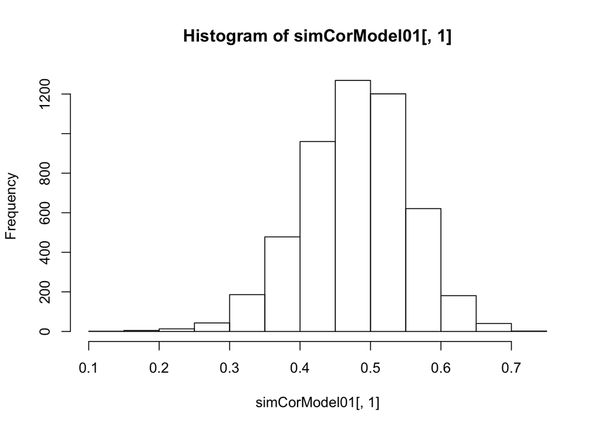

```r
# label values of simCor to ensure we have the right comparison
corNames = NULL
for (i in 1:(ncol(simData)-1)){
  for (j in (i+1):ncol(simData)){
    corNames = c(corNames, paste0("cor", i, "." , j))
  }
}
colnames(simCorModel01) = corNames

# show how one correlation compares to distribution of simulated correlations
dataCor = cor(conspiracy[paste0("PolConsp", 1:10)])
hist(simCorModel01[,1])
```

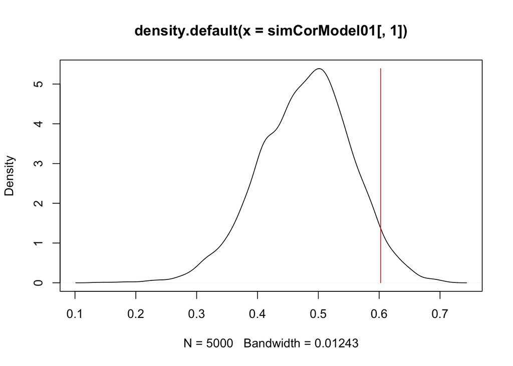

```r
plot(density(simCorModel01[,1]))
lines(x = c(dataCor[1,2], dataCor[1,2]), y = c(0, max(density(simCorModel01[,1])$y)), col = 2)
```

```r
quantile(simCorModel01[,1])
```

```
##        0%       25%       50%       75%      100%
## 0.1385092 0.4280912 0.4829562 0.5301677 0.7063892
```

```r
mean(simCorModel01[,1])
```

```
## [1] 0.4787558
```

```r
dataCor[1,2]
```

```
## [1] 0.6024186
```

```r
# create quantiles of correlations to see where each observed correlation falls
corQuantiles01 = NULL

# compute the quantiles of the observed correlations:
col = 1
for (i in 1:(ncol(simData)-1)){
  for (j in (i+1):ncol(simData)){
    # get empirical CDF of simulated correlation distribution
    corEcdf = ecdf(simCorModel01[,col])
    corQuantiles01 = rbind(corQuantiles01, c(i, j, summary(corEcdf), dataCor[i,j], corEcdf(dataCor[i,j])))

    col = col + 1
  }
}
colnames(corQuantiles01)[1:2] = c("Item 1", "Item 2")
colnames(corQuantiles01)[9:10] = c("ObsCor", "CorPctile")
corQuantiles01[which(corQuantiles01[,10] > .975 | corQuantiles01[,10] < .025),]
```

```
##       Item 1 Item 2       Min.   1st Qu.    Median      Mean   3rd Qu.
##  [1,]      1      9 0.32964808 0.6020599 0.6492998 0.6442087 0.6918183
##  [2,]      1     10 0.28359161 0.5469731 0.5975517 0.5933442 0.6436536
##  [3,]      2      7 0.33019051 0.6045640 0.6493305 0.6456857 0.6916046
##  [4,]      3      9 0.37798992 0.5972142 0.6421899 0.6391180 0.6848388
##  [5,]      4      7 0.50829881 0.7053104 0.7411647 0.7373292 0.7736674
##  [6,]      4      9 0.18507517 0.4047201 0.4608028 0.4573823 0.5143140
##  [7,]      5      6 0.14218321 0.4483043 0.5057352 0.5027756 0.5602961
##  [8,]      5      8 0.28844870 0.5824392 0.6321129 0.6273215 0.6785944
##  [9,]      6      8 0.04271822 0.3326313 0.3893071 0.3862449 0.4432259
## [10,]      7      8 0.14411586 0.4160441 0.4801927 0.4743181 0.5363882
##            Max.    ObsCor CorPctile
##  [1,] 0.8383943 0.4420860    0.0042
##  [2,] 0.7951318 0.2568334    0.0000
##  [3,] 0.8100302 0.4721628    0.0078
##  [4,] 0.8213189 0.3912734    0.0002
##  [5,] 0.9043838 0.4676834    0.0000
##  [6,] 0.6871472 0.6108052    0.9858
##  [7,] 0.7498141 0.7366890    0.9998
##  [8,] 0.8285709 0.7641703    0.9820
##  [9,] 0.6726612 0.7557355    1.0000
## [10,] 0.7214969 0.6611475    0.9906
```

### Comparing Model 0 (CFA) with Model 1 (IRT)

We can look at our results to see if there is a big difference in model fit or values of parameters:

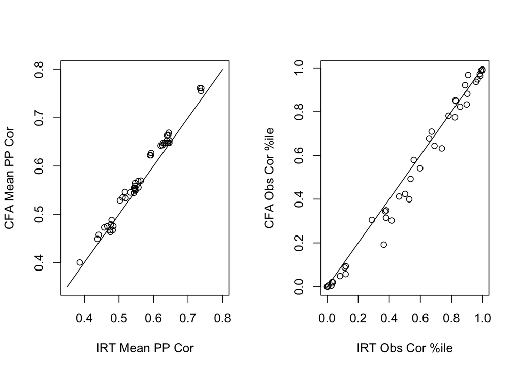

```r
par(mfrow = c(1,2))
# comparing results for model fit:
plot(x=corQuantiles01[,6], y=corQuantiles00[,6], xlab = "IRT Mean PP Cor", ylab = "CFA Mean PP Cor", ylim = c(.35,.80), xlim=c(.35,.8))
lines(c(.35,.8), c(.35,.8))
plot(x=corQuantiles01[,10], y=corQuantiles00[,10], xlab = "IRT Obs Cor %ile", ylab = "CFA Obs Cor %ile")
lines(c(0,1), c(0,1))
```

Now, let’s look at how the latent trait estimates compared:

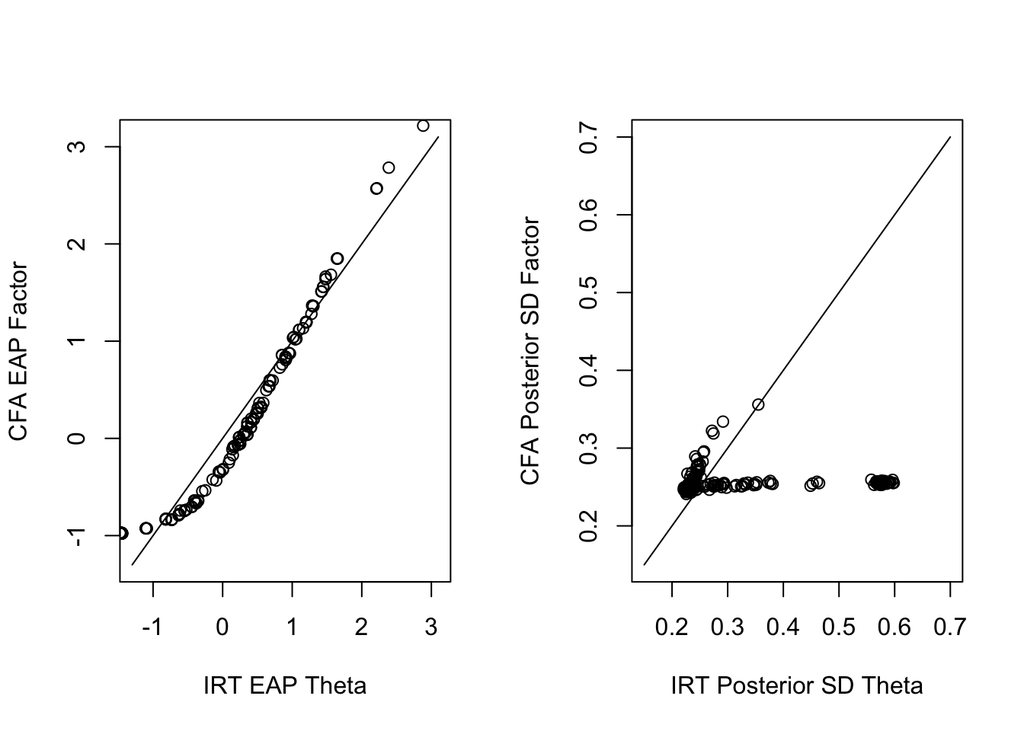

```r
ThetaCols00 = grep(x = colnames(model00.Posterior.all), pattern = "xfactor")
meanTheta00 = apply(X = model00.Posterior.all[,ThetaCols00], MARGIN = 2, FUN = mean)
sdTheta00 = apply(X = model00.Posterior.all[,ThetaCols00], MARGIN = 2, FUN = sd)

ThetaCols01 = grep(x = colnames(model01.Posterior.all), pattern = "theta")
meanTheta01 = apply(X = model01.Posterior.all[,ThetaCols01], MARGIN = 2, FUN = mean)
sdTheta01 = apply(X = model01.Posterior.all[,ThetaCols01], MARGIN = 2, FUN = sd)

par(mfrow = c(1,2))
# comparing results for model fit:
plot(x=meanTheta01, y=meanTheta00, xlab = "IRT EAP Theta", ylab = "CFA EAP Factor", ylim = c(-1.3, 3.1), xlim = c(-1.3, 3.1))
lines(c(-1.3, 3.1),c(-1.3, 3.1))
plot(x=sdTheta01, y=sdTheta00, xlab = "IRT Posterior SD Theta", ylab = "CFA Posterior SD Factor", ylim = c(.15, .7), xlim = c(.15, .7))
lines(c(.15, .7),c(.15, .7))
```

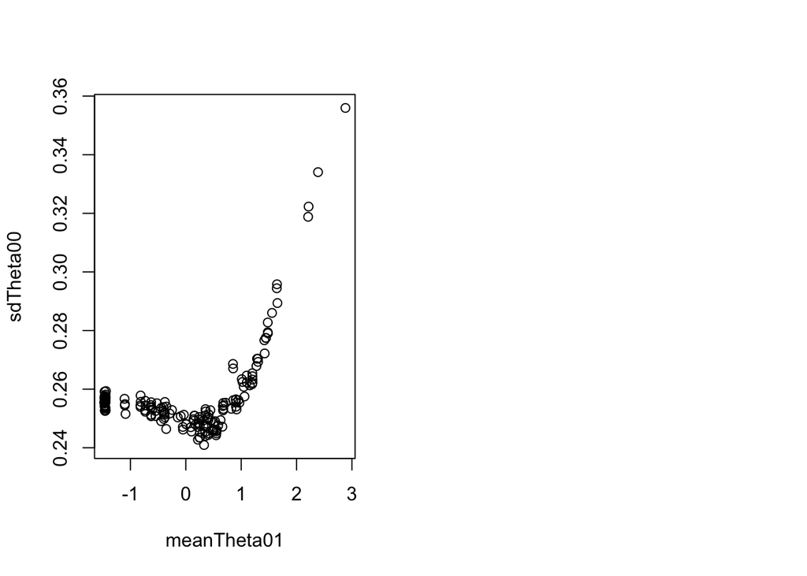

```r
plot(x=meanTheta01, y=sdTheta00)

par(mfrow = c(1,1))
```

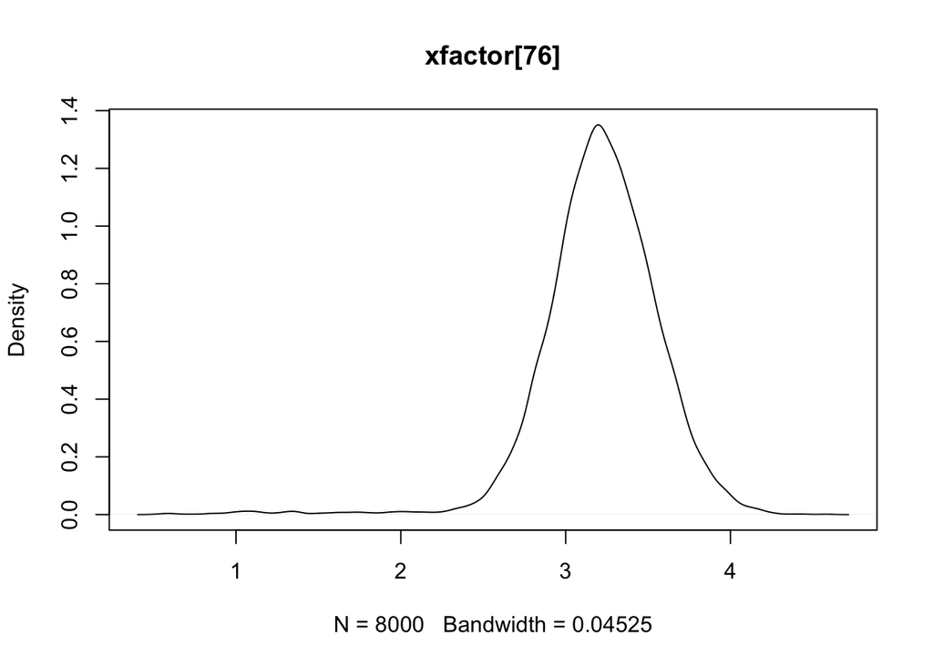

```r
plot(density(model00.Posterior.all[, which(colnames(model00.Posterior.all) ==names(which.max(sdTheta00)))]), main=names(which.max(sdTheta00)))
```

```r
conspiracy[76,]
```

```
##    PolConsp1 PolConsp2 PolConsp3 PolConsp4 PolConsp5 PolConsp6 PolConsp7
## 76         2         5         5         5         5         5         5
##    PolConsp8 PolConsp9 PolConsp10 female
## 76         5         5          5      0
```

### Model 2: Unidimensional Generalized Partial Model

```r
# marker item:
model02.function = function(){

  # measurement model specification
    for (person in 1:N){
      for (item in 1:I){

        for (cat in 1:C[I]){
          eta[person, item, cat] <- a[item] * (theta[person] - b[item, cat])
          psum[person, item, cat] <- sum(eta[person, item, 1:cat])
          exp.psum[person, item, cat] <- exp(psum[person, item, cat])
          prob[person, item, cat] <- exp.psum[person, item, cat]/sum(exp.psum[person, item, 1:C[item]])
        }

        X[person, item] ~ dcat(prob[person, item, 1:C[item]])
      }
    }

  # prior distributions for the factor:
    for (person in 1:N){
      theta[person] ~ dnorm(0, 1)
    }

  # prior distributions for the measurement model mean/precision parameters
    for (item in 1:I){

      b[item, 1] <- 0

      # create parameters that are unbounded, then sort
      for (cat in 2:C[item]){
        b[item, cat] ~ dnorm(b.mean.0, b.precision.0)
      }

      # loadings are set to be all positive
      a[item] ~ dnorm(a.mean.0, a.precision.0);T(0,)

    }

}
```

```r
nItems = 10

# specification of prior values for measurement model parameters:
#   item intercepts
b.mean.0 = 0
b.variance.0 = 100
b.precision.0 = 1 / b.variance.0

#   Factor loadings -- these are the discriminations
a.mean.0 = 0
a.variance.0 = 100
a.precision.0 = 1 / a.variance.0

# next, create data for JAGS to use:
model02.data = list(
  N = nrow(conspiracy),
  X = conspiracy,
  C = unlist(apply(X = conspiracy[,1:10], MARGIN = 2, FUN = max)),
  I = 10,
  b.mean.0 = b.mean.0,
  b.precision.0 = b.precision.0,
  a.mean.0 = a.mean.0,
  a.precision.0 = a.precision.0
)

model02.init = function(){
  list("a" = runif(10, 1, 2),
       "b" = cbind(rep(NA, 10), rep(1, 10), rep(0, 10), rep(-1, 10), rep(-2, 10)))
}

model02.parameters = c("a", "b",  "theta")

model02.seed = 16042019 + 1
```

Here, we will use the R2jags `jags.parallel()` function, which will run somewhat faster (one chain per core):

```r
model02.r2jags =  jags.parallel(
  data = model02.data,
  inits = model02.init,
  parameters.to.save = model02.parameters,
  model.file = model02.function,
  n.chains = 4,
  n.iter = 2000,
  n.thin = 1,
  n.burnin = 1000,
  jags.seed = model02.seed
)

model02.r2jags
```

```
## Inference for Bugs model at "model02.function", fit using jags,
##  4 chains, each with 2000 iterations (first 1000 discarded)
##  n.sims = 4000 iterations saved
##             mu.vect sd.vect     2.5%      25%      50%      75%    97.5%
## a[1]          0.996   0.174    0.671    0.873    0.991    1.113    1.347
## a[2]          1.608   0.273    1.110    1.419    1.591    1.778    2.193
## a[3]          1.228   0.203    0.871    1.084    1.213    1.355    1.657
## a[4]          1.639   0.275    1.160    1.441    1.622    1.817    2.219
## a[5]          3.048   0.565    2.128    2.651    2.991    3.382    4.281
## a[6]          3.414   0.629    2.332    2.966    3.370    3.806    4.761
## a[7]          1.641   0.298    1.115    1.433    1.621    1.828    2.277
## a[8]          3.502   0.702    2.281    3.027    3.431    3.929    5.034
## a[9]          1.463   0.288    0.955    1.256    1.449    1.646    2.068
## a[10]         1.153   0.252    0.692    0.982    1.140    1.314    1.708
## b[1,1]        0.000   0.000    0.000    0.000    0.000    0.000    0.000
## b[2,1]        0.000   0.000    0.000    0.000    0.000    0.000    0.000
## b[3,1]        0.000   0.000    0.000    0.000    0.000    0.000    0.000
## b[4,1]        0.000   0.000    0.000    0.000    0.000    0.000    0.000
## b[5,1]        0.000   0.000    0.000    0.000    0.000    0.000    0.000
## b[6,1]        0.000   0.000    0.000    0.000    0.000    0.000    0.000
## b[7,1]        0.000   0.000    0.000    0.000    0.000    0.000    0.000
## b[8,1]        0.000   0.000    0.000    0.000    0.000    0.000    0.000
## b[9,1]        0.000   0.000    0.000    0.000    0.000    0.000    0.000
## b[10,1]       0.000   0.000    0.000    0.000    0.000    0.000    0.000
## b[1,2]       -0.582   0.242   -1.033   -0.745   -0.589   -0.431   -0.074
## b[2,2]        0.117   0.164   -0.186    0.008    0.110    0.221    0.463
## b[3,2]        0.840   0.261    0.404    0.655    0.820    1.000    1.404
## b[4,2]        0.096   0.170   -0.219   -0.024    0.089    0.206    0.445
## b[5,2]       -0.045   0.119   -0.281   -0.125   -0.046    0.037    0.184
## b[6,2]        0.032   0.115   -0.202   -0.042    0.036    0.113    0.244
## b[7,2]        0.586   0.184    0.268    0.456    0.571    0.697    0.996
## b[8,2]        0.126   0.117   -0.109    0.050    0.128    0.202    0.354
## b[9,2]        0.630   0.205    0.279    0.486    0.613    0.753    1.094
## b[10,2]       1.726   0.415    1.091    1.443    1.665    1.933    2.729
## b[1,3]        0.239   0.239   -0.244    0.086    0.247    0.394    0.705
## b[2,3]        0.841   0.188    0.481    0.717    0.835    0.959    1.213
## b[3,3]        0.214   0.244   -0.290    0.064    0.231    0.376    0.664
## b[4,3]        0.496   0.172    0.148    0.387    0.500    0.613    0.826
## b[5,3]        0.751   0.129    0.508    0.665    0.750    0.839    1.010
## b[6,3]        0.717   0.118    0.482    0.640    0.717    0.795    0.951
```

[output cut: 433 more lines]

```
## theta[171] 1.004   870
## theta[172] 1.003  1000
## theta[173] 1.002  4000
## theta[174] 1.001  4000
## theta[175] 1.003  1100
## theta[176] 1.001  4000
## theta[177] 1.002  1700
## deviance   1.002  2200
##
## For each parameter, n.eff is a crude measure of effective sample size,
## and Rhat is the potential scale reduction factor (at convergence, Rhat=1).
##
## DIC info (using the rule, pD = var(deviance)/2)
## pD = 279.1 and DIC = 3160.1
## DIC is an estimate of expected predictive error (lower deviance is better).
```

## Model 3: Nominal Response Model

```r
# marker item:
model03.function = function(){

  # measurement model specification
    for (person in 1:N){
      for (item in 1:I){

        for (cat in 1:C[I]){
          cnum[person, item, cat] <- exp(a[item, cat] * (theta[person] - b[item, cat]))
          prob[person, item, cat] <- cnum[person, item, cat]/sum(cnum[person, item, 1:C[item]])
        }

        X[person, item] ~ dcat(prob[person, item, 1:C[item]])
      }
    }

  # prior distributions for the factor:
    for (person in 1:N){
      theta[person] ~ dnorm(0, 1)
    }

  # prior distributions for the measurement model mean/precision parameters
    for (item in 1:I){

      # create parameters that are unbounded, then sort
      for (cat in 1:(C[item]-1)){
        b[item, cat+1] ~ dnorm(b.mean.0, b.precision.0)
        a[item, cat+1] ~ dnorm(a.mean.0, a.precision.0)
      }
      b[item, 1] <- 0
      a[item, 1] <- 0

    }

}
```

```r
nItems = 10

# specification of prior values for measurement model parameters:
#   item intercepts
b.mean.0 = 0
b.variance.0 = 1
b.precision.0 = 1 / b.variance.0

#   Factor loadings -- these are the discriminations
a.mean.0 = 0
a.variance.0 = 1
a.precision.0 = 1 / a.variance.0

# next, create data for JAGS to use:
model03.data = list(
  N = nrow(conspiracy),
  X = conspiracy,
  C = unlist(apply(X = conspiracy[,1:10], MARGIN = 2, FUN = max)),
  I = 10,
  b.mean.0 = b.mean.0,
  b.precision.0 = b.precision.0,
  a.mean.0 = a.mean.0,
  a.precision.0 = a.precision.0
)

model03.init = function(){
  list("a" = cbind(rep(NA, 10), runif(10), runif(10), runif(10), runif(10)),
       "b" = cbind(rep(NA, 10), runif(10), runif(10), runif(10), runif(10)))
}

model03.parameters = c("a", "b",  "theta")

model03.seed = 16042019 + 2
```

Here, we will use the R2jags `jags.parallel()` function, which will run somewhat faster (one chain per core):

```r
model03.r2jags =  jags.parallel(
  data = model03.data,
  inits = model03.init,
  parameters.to.save = model03.parameters,
  model.file = model03.function,
  n.chains = 4,
  n.iter = 2000,
  n.thin = 1,
  n.burnin = 1000,
  jags.seed = model03.seed
)

model03.r2jags
```

```
## Inference for Bugs model at "model03.function", fit using jags,
##  4 chains, each with 2000 iterations (first 1000 discarded)
##  n.sims = 4000 iterations saved
##             mu.vect sd.vect     2.5%      25%      50%      75%    97.5%
## a[1,1]        0.000   0.000    0.000    0.000    0.000    0.000    0.000
## a[2,1]        0.000   0.000    0.000    0.000    0.000    0.000    0.000
## a[3,1]        0.000   0.000    0.000    0.000    0.000    0.000    0.000
## a[4,1]        0.000   0.000    0.000    0.000    0.000    0.000    0.000
## a[5,1]        0.000   0.000    0.000    0.000    0.000    0.000    0.000
## a[6,1]        0.000   0.000    0.000    0.000    0.000    0.000    0.000
## a[7,1]        0.000   0.000    0.000    0.000    0.000    0.000    0.000
## a[8,1]        0.000   0.000    0.000    0.000    0.000    0.000    0.000
## a[9,1]        0.000   0.000    0.000    0.000    0.000    0.000    0.000
## a[10,1]       0.000   0.000    0.000    0.000    0.000    0.000    0.000
## a[1,2]        1.166   0.258    0.664    0.985    1.163    1.347    1.677
## a[2,2]        1.186   0.227    0.761    1.031    1.181    1.334    1.639
## a[3,2]        1.350   0.267    0.868    1.160    1.340    1.530    1.894
## a[4,2]        1.530   0.258    1.058    1.350    1.525    1.699    2.060
## a[5,2]        1.350   0.256    0.869    1.169    1.338    1.518    1.869
## a[6,2]        1.684   0.275    1.160    1.500    1.674    1.858    2.265
## a[7,2]        1.233   0.235    0.806    1.070    1.227    1.392    1.708
## a[8,2]        1.394   0.260    0.916    1.213    1.386    1.556    1.934
## a[9,2]        1.277   0.242    0.839    1.111    1.270    1.434    1.778
## a[10,2]       1.404   0.285    0.884    1.210    1.388    1.592    1.998
## a[1,3]        1.745   0.298    1.210    1.529    1.740    1.944    2.357
## a[2,3]        2.284   0.369    1.617    2.025    2.259    2.512    3.052
## a[3,3]        1.491   0.268    0.988    1.309    1.483    1.663    2.053
## a[4,3]        2.220   0.317    1.643    2.001    2.214    2.425    2.888
## a[5,3]        2.726   0.397    2.021    2.446    2.703    2.972    3.582
## a[6,3]        2.583   0.358    1.906    2.339    2.572    2.823    3.331
## a[7,3]        1.907   0.334    1.300    1.681    1.896    2.113    2.584
## a[8,3]        2.447   0.375    1.781    2.187    2.420    2.674    3.281
## a[9,3]        2.022   0.388    1.318    1.752    2.002    2.266    2.843
## a[10,3]       1.733   0.366    1.062    1.475    1.716    1.964    2.490
## a[1,4]        1.369   0.299    0.794    1.166    1.359    1.557    1.979
## a[2,4]        1.744   0.370    1.095    1.474    1.728    1.988    2.528
## a[3,4]        2.058   0.457    1.233    1.741    2.041    2.339    3.030
## a[4,4]        1.909   0.422    1.135    1.615    1.893    2.181    2.789
## a[5,4]        2.237   0.423    1.464    1.944    2.227    2.516    3.107
## a[6,4]        2.839   0.504    1.861    2.496    2.839    3.189    3.823
```

[output cut: 513 more lines]

```
## theta[171] 1.002  1400
## theta[172] 1.001  2800
## theta[173] 1.001  4000
## theta[174] 1.001  2900
## theta[175] 1.002  2300
## theta[176] 1.001  4000
## theta[177] 1.003  1100
## deviance   1.001  4000
##
## For each parameter, n.eff is a crude measure of effective sample size,
## and Rhat is the potential scale reduction factor (at convergence, Rhat=1).
##
## DIC info (using the rule, pD = var(deviance)/2)
## pD = 537.0 and DIC = 3589.8
## DIC is an estimate of expected predictive error (lower deviance is better).
```